# Music Artist Popularity

10 January 2024

### Introduction

Rolling Stone ranked 100 greatest musical artists of all time in 2010. The article claims them the “most influential artists of the rock & roll era”, but has their music endured? The analysis below describes characteristics that may explain popularity at the end of 2023.

### Data

I used three data sources in my analysis.

1. The Rolling Stone’s 100 Greatest Artists (RS100) article, which I accessed by scraping the website to get artist name, rank, and description. No data manipulation was needed after collection. All 3 variables were stored in a single table.
2. The Spotify API, which I accessed using the “spotifyr” package. I gathered two categories of data: information about the RS100 artists and top tracks. I did not manipulate data further than turning numbers into numeric data types and changing song duration from milliseconds to minutes. All data for the 83 artists (out of 100) that had spotify information available were stored in a single table with 10 columns.
3. The wikipedia article “List of best-selling music artists’’ which contains tables of information about the best-selling music artists. I used a webscraper to access the data and functions to clean the data (primary parse numbers for monetary values). This data contained 31 out of the 100 artists from the Rolling Stone article and was stored as a table with 8 columns.

I saved all three tables to a database and used SQLite queries for my analysis.

### Analysis

*Note Spotify data includes 83 out of the RS100. Wikipedia best-sellers include 31 out of the RS100.*

The table shows the most relatively frequent genres in the spotify API data and best-sellers wikipedia data. Both lists indicate that the most common genres are rock related.

```
##       Spotify_Genre S_Relative_Freq Wiki_Genre W_Relative_Freq
## 1              rock            7.99       rock            7.19
## 2      classic rock            5.99        pop            4.94
## 3        album rock            3.27        r&b            1.80
## 4              soul            3.09       soul            1.80
## 5 singer-songwriter            2.91 blues rock            1.35
```

The histograms below show the distribution of release year of the top track compared with the release year of the artist’s first charted record. Both charts indicate that the RS100 largely became famous between the 1960s-1980s, the height of rock music.

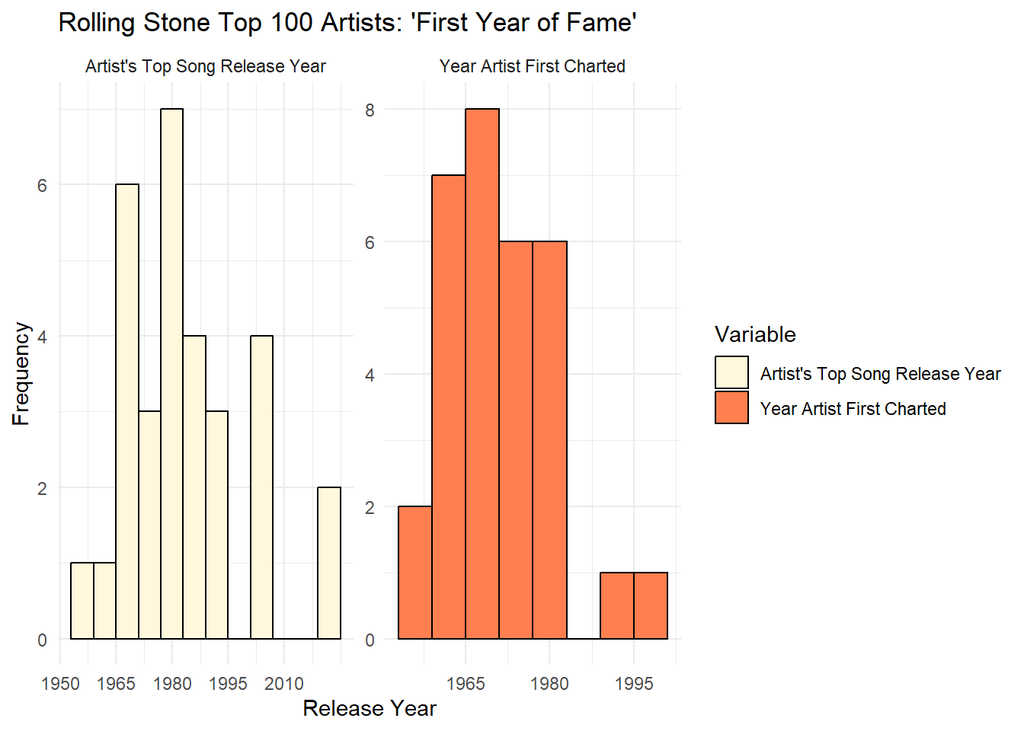

This histogram shows the distribution of Spotify artist popularity scores. The scores are between 0 (lowest) and 100 (highest). The chart indicates that the scores are not uniquely high, with the majority being between 53 and 83.

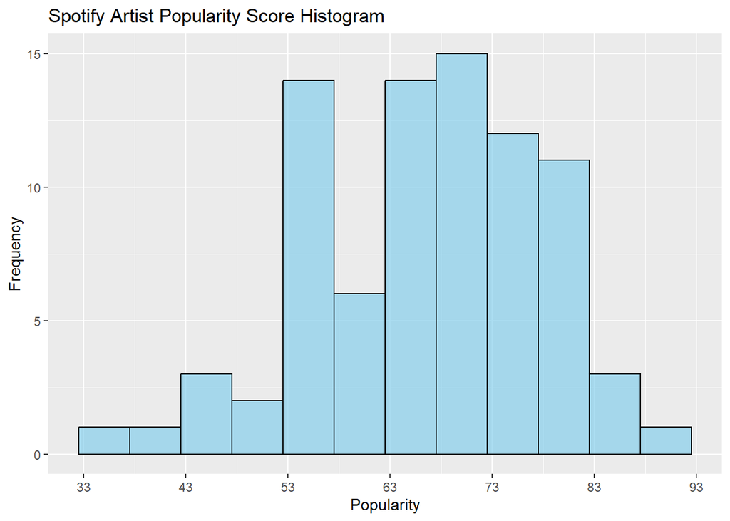

The scatterplot below indicates that Rolling Stone ranking does not correlate with Spotify popularity.

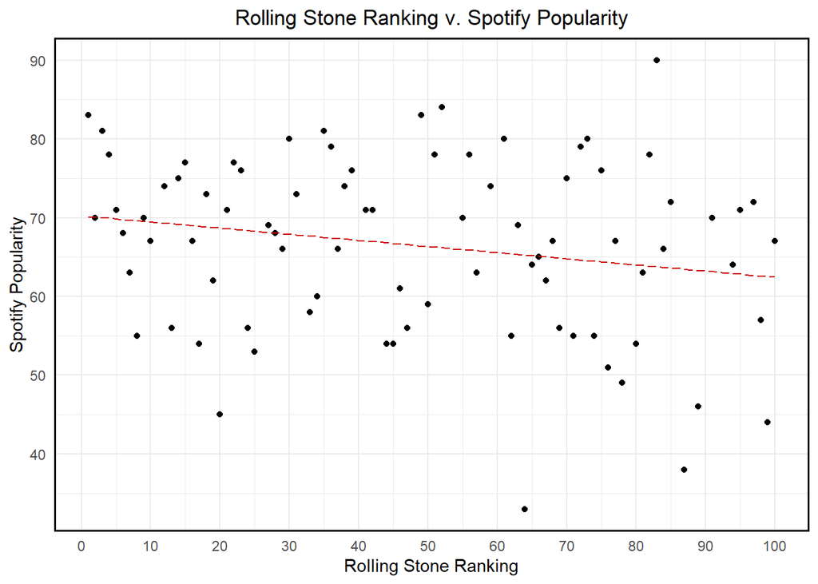

The table below shows the top 10 artists for Spotify popularity. These artists all have popular top songs, rock genres, millions in certified sales (units), and all from the US, UK, or Australia. What explains why these artists are popular compared to others from the RS100?

```
##    RS_Rank          Artist Popularity TopTrack_Popularity TopTrack_ReleaseDate
## 1       83          Eminem         90                  92           2002-05-26
## 2       52           Queen         84                  77           1978-11-10
## 3       49      Elton John         83                  90           2021-12-03
## 4        1     The Beatles         83                  86           1969-09-26
## 5        3   Elvis Presley         81                  90           1957-10-15
## 6       35 Michael Jackson         81                  82           1982-11-30
## 7       61       Metallica         80                  78           1991-08-12
## 8       30         Nirvana         80                  80           1991-09-26
## 9       72           AC/DC         79                  87           1979-07-27
## 10      36         Madonna         79                  94           2023-06-02
##           Country Certified_Units
## 1   United States       332850000
## 2  United Kingdom       186000000
## 3  United Kingdom       212500000
## 4  United Kingdom       293200000
## 5   United States       234100000
## 6   United States       285400000
## 7   United States       106000000
## 8   United States        57200000
## 9       Australia       131100000
## 10  United States       184800000
```

The scatterplot below shows Artist Popularity is correlated with Top-Song popularity. The API indicates Artist Popularity is partially dependent on song popularity. This could indicate that artists who have even one popular song (“one hit wonders”) may have higher popularity scores. The Rolling Stone article sought to describe the most influential artists, which may not be those with popular songs, but rather artists who explored and revolutionized music in a way that inspired other musicians. This may explain the lack of correlation between the Rolling Stone ranking and Spotify Popularity metrics. It also explains why some of the RS100 scored poorly on Spotify Popularity.

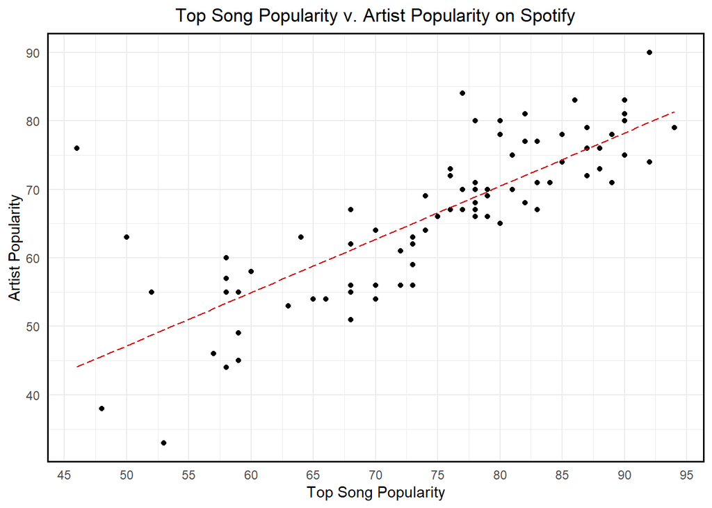

It appears there is a slight correlation between the song’s release year and the artist’s popularity. This indicates that older artists may have lower popularity scores because their songs were released earlier.

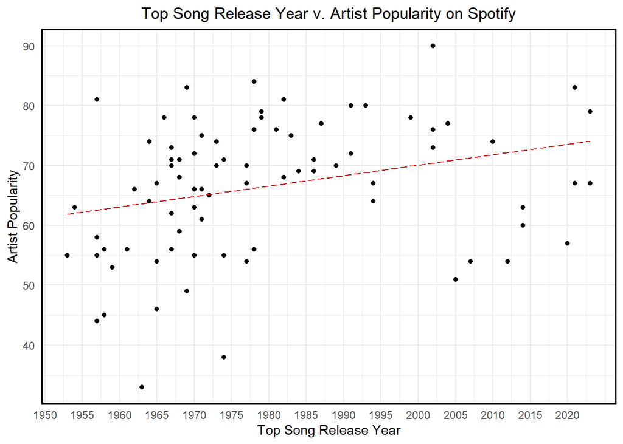

The graph below indicates there is a relationship between artist popularity and certified sales. Artists who have more popularity may make more money from streams, advertising their music and continuing to gain money and popularity. The interesting factor is that these numbers are largely from a pre-streaming world as the artists tend to be from older years. This may indicate that artists who sold more records in the height of their fame are more likely to see success on streaming apps than those who sold less.

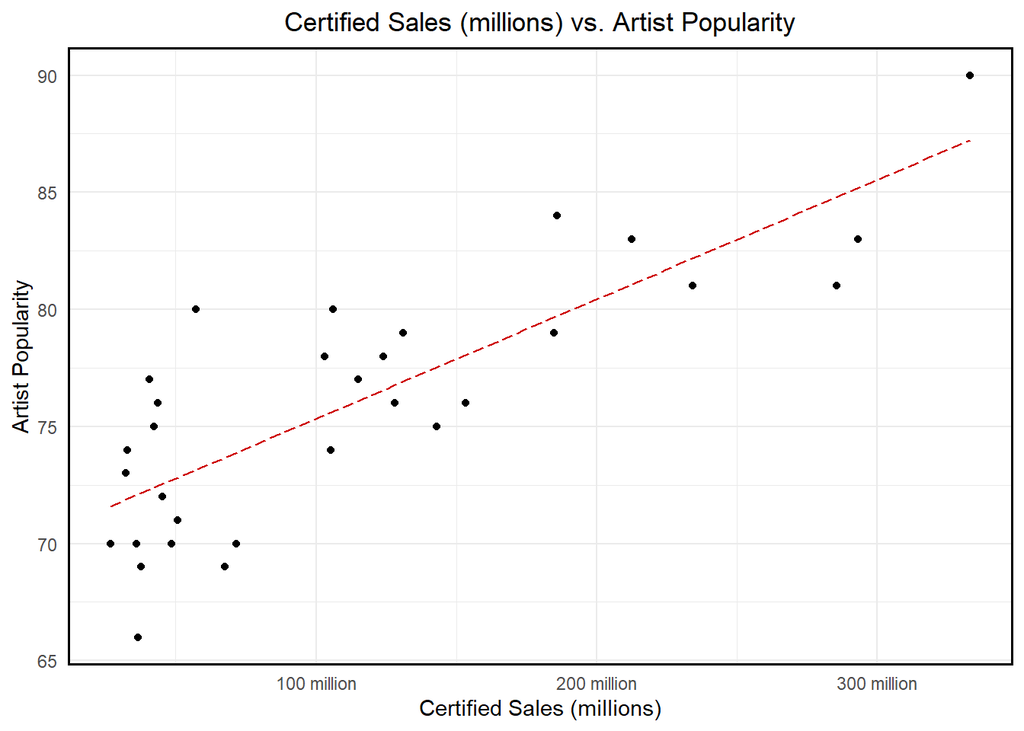

Data shows that some of the RS100 have music that endures, but many have low popularity scores on spotify. Artists with more popular Top-Songs, Top-Songs with later release dates, and more certified sales tend to have higher popularity scores. While the Rolling Stone sought to find those with the most influence on (rock) music, this analysis indicates that those who had the most influence may not endure as other factors better determine streaming popularity. Regardless, we can still appreciate the influence all these musicians had and continue to have in the music world.

### Appendix

```r
knitr::opts_chunk$set(echo = FALSE)

# IMPORTS ----------------------------------------------------------------------
library(tidyverse)
library(DBI)
library(RSelenium)
library(netstat)
library(spotifyr)
library(dplyr)
library(rvest)
library(ggplot2)

# DATABASE ---------------------------------------------------------------------

# Create SQLite database
database_name <- "database/top_artists-db.sqlite"
db <- dbConnect(RSQLite::SQLite(), database_name)

# FUNCTIONS --------------------------------------------------------------------

# ROLLING STONE DATA PROCESSING FUNCTIONS---------------------------------------

# Get list of elements given a selector (given driver has navigated to URL)
get_RStop100_element <- function(selector) {

  # Get elements from selector, transform to text, return as vector
  elements <- driver$findElements(using = "xpath", value = selector)
  selected_items <- sapply(elements, function(element) element$getElementText())
  return(unlist(selected_items))
}

# SPOTIFY API DATA PROCESSING FUNCTIONS-----------------------------------------

# Get artists info given their name (using Spotify API)
get_artist_info <- function(name) {

  # Search for artist to get Spotify ID
  artist_search_results <- search_spotify(name,'artist')
  artist_id <- artist_search_results$id[[1]]

  # Get artist info and return
  artist_info <- get_artist(artist_id)
  return(artist_info)
}

# Return artist name, popularity, genres, number of genres (artist_info table)
get_popularity_vars <- function(artist_info) {

  # Get values for each popularity variable and return
  spotify_id <- artist_info$id
  name <- artist_info$name
  popularity <- artist_info$popularity
  genres <- paste(artist_info$genres, collapse = ", ")
  num_genres <- length(artist_info$genres)

  return(c(spotify_id,name,popularity,genres,num_genres))
}

# Get artists top track info given their name (using Spotify API)
get_toptrack_info <- function(name) {

  # Search for artist to get Spotify ID
  artist_search_results <- search_spotify(name,'artist')
  artist_id <- artist_search_results$id[[1]]

  # Get top track info and return
  top_tracks <- get_artist_top_tracks(artist_id)
  top_song_name <- top_tracks$name[[1]]
  top_song_pop <- top_tracks$popularity[[1]]
  top_song_len <- top_tracks$duration_ms[[1]]
  top_song_releasedate <- top_tracks$album.release_date[[1]]

  return(c(name,top_song_name,top_song_pop,top_song_len,top_song_releasedate))
}

# WIKIPEDIA TOP SELLERS DATA PROCESSING FUNCTIONS-------------------------------

# Remove bracket numbers from character string (clean Wiki tables)
remove_bracket_num <- function(input_string) {

  # Return string without bracket numbers
  updated_string <- gsub("\\[\\d+\\]", "", input_string)
  return(updated_string)
}

# Function to parse claimed sales to single number (clean Wiki tables)
parse_claimed_sales <- function(chars) {

  # Parse string into list of numbers and convert to millions
  parse_num_pattern <- "\\b\\d{1,3}(,\\d{3})*(\\.\\d+)?\\b"
  all_numbers <- str_extract_all(chars, parse_num_pattern)
  all_numbers <- as.numeric(gsub(",", "", unlist(all_numbers)))
  all_numbers <- unlist(lapply(all_numbers,function(i){i*1000000}))

  # Return mean
  return(mean(all_numbers))
}

# Function to parse certified sales to single number (clean Wiki tables)
parse_cert_sales <- function(chars) {

  # Parse string into list of numbers
  parse_num_pattern <- "\\b\\d{1,3}(,\\d{3})*(\\.\\d+)?\\b"
  all_numbers <- unlist(str_extract_all(chars, parse_num_pattern))

  # Handle case where parse output .hidden message appears
  if (grepl(".hidden", chars)) {
    num_cert_sales <- as.numeric(all_numbers[[4]])*1000000
    return(num_cert_sales) }

  # Return first number and convert to millions
  first_number <- as.numeric(all_numbers[[1]])*1000000
  return(first_number)
}

# Clean list of genres (clean Wiki tables)
clean_genres <- function(input_string) {

  # Return cleaned list of genres
  updated_string <- gsub(" /",",",input_string)
  return(updated_string)
}

# Function to clean Wikipedia table (clean Wiki tables)
clean_wiki_table <- function(table) {

  # Update header
  colnames(table) <- c("Artist","Country","Period_Active","Year_First_Charted",
                       "Genre","Certified_Units","Claimed_Sales")

  # Clean columns using wiki_table cleaning functions above
  table <- table %>%
    mutate_all(remove_bracket_num) %>%
    mutate(Claimed_Sales = sapply(lapply(Claimed_Sales, parse_claimed_sales), `[`, 1)) %>%
    mutate(Certified_Units = sapply(lapply(Certified_Units, parse_cert_sales), `[`, 1)) %>%
    mutate(Genre = sapply(lapply(Genre,clean_genres), `[`, 1))

  table$Claimed_Sales <- format(table$Claimed_Sales, scientific = FALSE)
  table$Certified_Units <- format(table$Certified_Units, scientific = FALSE)

  # Return table
  return(table)
}

# GENRE DATA PROCESSING FUNCTIONS-----------------------------------------------

get_top_genres <- function(genre_column) {

  # Split column by comma and create list of all genres
  split_genre_list <- lapply(strsplit(genre_column, ", "), trimws)
  lowercase_genre_list <- unlist(lapply(split_genre_list, tolower), recursive = FALSE)

  # Calculate relative frequencies
  genre_table <- table(lowercase_genre_list)
  relative_frequencies <- round(prop.table(genre_table) * length(genre_column), digits = 2)

  # Return sorted list of relative frequencies
  sorted_relative_frequencies <- sort(relative_frequencies, decreasing = TRUE)
  return(sorted_relative_frequencies)
}


# DATA PROCESSING: THE ROLLING STONE TOP 100 ARTISTS (2010) --------------------

# XPATH selectors
ranking_selector <- '//*[@class="c-gallery-vertical-album__number"]'
artist_selector <- '//*[@class="c-gallery-vertical-album__title"]'
essay_selector <- '//*[@class="c-gallery-vertical-album__description"]'

# Setup driver and Navigate to URL (first half of top 100 list)
rD <- rsDriver(browser = c("firefox"), port = free_port(random = TRUE), chromever = NULL)
driver <- rD$client
url <- 'https://www.rollingstone.com/music/music-lists/100-greatest-artists-147446/'
driver$navigate(url)
```

```r
# Get information for first 50 artists (#100-51)
ranking_first <- get_RStop100_element(ranking_selector)
artists_first <- get_RStop100_element(artist_selector)
essays_first <- get_RStop100_element(essay_selector)

# Load page with second half of top 100 list
to_scroll <- driver$findElement(using = "xpath", value = '/html/body/div[5]/main/div[2]/div[1]/div/article/div[3]/div[2]/div[2]/a')
driver$executeScript("arguments[0].scrollIntoView(true);", list(to_scroll))
below_50 <- driver$findElement(using = 'xpath', value = '/html/body/div[5]/header/div[2]/div/div/div/div/aside/div/div[2]/a[6]')
below_50$clickElement()

# Get information for second 50 artists (#50-1)
ranking_second <- get_RStop100_element(ranking_selector)
artists_second <- get_RStop100_element(artist_selector)
essays_second <- get_RStop100_element(essay_selector)

# Combine info for first and second 50 (for total of 100)
ranking <- c(ranking_first, ranking_second)
artists <- c(artists_first, artists_second)
essays <- c(essays_first, essays_second)

# Create table with variables for Ranking, Artist name, and Essay (description of legacy)
rollingstone_top100 <- data.frame(Rank = as.numeric(ranking), Artist = artists, Essay = essays)

# Save table to database
db <- dbConnect(RSQLite::SQLite(),database_name)
dbWriteTable(db, "rollingstone_top100", rollingstone_top100, overwrite = TRUE, primary.key = "Artist")
dbDisconnect(db)


# DATA PROCESSING: SPOTIFY API -------------------------------------------------

# Access Spotify API
readRenviron("../spotify_api.env")
Sys.setenv(SPOTIFY_CLIENT_ID = Sys.getenv("CLIENT_ID"),
           SPOTIFY_CLIENT_SECRET = Sys.getenv("CLIENT_SECRET"))

# Loop over Rolling Stone Artists to get Spotify Info
artist_info <- data.frame()
toptrack_info <- data.frame()
for (artist in top100_table$Artist) {

  # Get artist popularity variables and save to dataframe
  pop_vars <- get_popularity_vars(get_artist_info(artist))
  artist_info <- rbind(artist_info, pop_vars)

  # Get artist top track info and save to dataframe
  top_track <- get_toptrack_info(artist)
  toptrack_info <- rbind(toptrack_info, top_track)
}

# Update column names and merge dataframes for artist and top track
colnames(artist_info) <- c("ID","Artist","Popularity","Genres","Num_Genres")
colnames(toptrack_info) <- c("Artist","TopTrack_Name","TopTrack_Popularity","TopTrack_Duration","TopTrack_ReleaseDate")
spotify_info <- merge(artist_info,toptrack_info,by = "Artist")

# Update columns to be numeric
spotify_info$Popularity <- as.numeric(spotify_info$Popularity)
spotify_info$Num_Genres <- as.numeric(spotify_info$Num_Genres)
spotify_info$TopTrack_Popularity <- as.numeric(spotify_info$TopTrack_Popularity)
spotify_info$TopTrack_Duration <- as.numeric(spotify_info$TopTrack_Duration)/60000

view(spotify_info)

# Save spotify_info table to database
db <- dbConnect(RSQLite::SQLite(),database_name)
dbWriteTable(db, "spotify_info", spotify_info, overwrite = TRUE, primary.key = "Artist")
dbDisconnect(db)

# Add column for Release Year (based on Release Date)
db <- dbConnect(RSQLite::SQLite(),database_name)
dbExecute(db, "ALTER TABLE spotify_info ADD COLUMN Release_Year INTEGER;")
dbExecute(db, "UPDATE spotify_info
SET Release_Year =
  CASE
    WHEN TopTrack_ReleaseDate LIKE '____-__-__' THEN -- Check for YYYY-MM-DD format
      CAST(SUBSTR(TopTrack_ReleaseDate, 1, 4) AS INTEGER)
    WHEN TopTrack_ReleaseDate LIKE '____' THEN -- Check for YYYY format
      CAST(TopTrack_ReleaseDate AS INTEGER)
    WHEN TopTrack_ReleaseDate LIKE '____-__' THEN -- Check for YYYY-MM format
      CAST(SUBSTR(TopTrack_ReleaseDate, 1, 4) AS INTEGER)
    ELSE
      NULL -- Handle cases where the date format is not recognized
  END;")


# DATA PROCESSING: WIKIPEDIA BEST SELLERS --------------------------------------

# Get list of tables on wikipedia page
wiki_url <- 'https://en.wikipedia.org/wiki/List_of_best-selling_music_artists#250_million_or_more_records'
html <- read_html(wiki_url)
tables <- html_table(html, fill = TRUE)

# Apply Wiki table cleaning function
above_250mill <- clean_wiki_table(tables[[1]])
above_200mill <- clean_wiki_table(tables[[2]])
above_120mill <- clean_wiki_table(tables[[3]])
above_100mill <- clean_wiki_table(tables[[4]])
above_80mill <- clean_wiki_table(tables[[5]])
above_75mill <- clean_wiki_table(tables[[6]])

# Combine all tables into one
top_sellers <- bind_rows(
  above_250mill %>% mutate(Category = "Above 250 Million"),
  above_200mill %>% mutate(Category = "Above 200 Million"),
  above_120mill %>% mutate(Category = "Above 120 Million"),
  above_100mill %>% mutate(Category = "Above 100 Million"),
  above_80mill %>% mutate(Category = "Above 80 Million"),
  above_75mill %>% mutate(Category = "Above 75 Million")
)

# Save table to database
db <- dbConnect(RSQLite::SQLite(),database_name)
dbWriteTable(db, "top_sellers", top_sellers, overwrite = TRUE, primary.key = "Artist")
dbDisconnect(db)

# SQL QUERIES TO RETRIEVE TABLES FROM DATABASE----------------------------------

db <- dbConnect(RSQLite::SQLite(),database_name)

spotify_info <- dbGetQuery(db,
  "SELECT * FROM spotify_info")

all_artist_data <- dbGetQuery(db,
  "SELECT rs.Rank as RS_Rank, si.*,
  ts.Country, ts.Period_Active, ts.Year_First_Charted, ts.Genre AS Wiki_Genre,
  ts.Certified_Units, ts.Claimed_Sales
    FROM spotify_info AS si
    JOIN top_sellers AS ts ON ts.Artist = si.Artist
    JOIN rollingstone_top100 AS rs ON rs.Artist = si.Artist")

popularity_table <- dbGetQuery(db,
  "SELECT spotify_info.Artist,
  rollingstone_top100.Rank AS RS_Rank,
  spotify_info.Popularity, spotify_info.TopTrack_Popularity
  FROM spotify_info
  JOIN rollingstone_top100 ON spotify_info.Artist = rollingstone_top100.Artist;")

top_10_most_popular <- dbGetQuery(db,
  "SELECT rs.Rank AS RS_Rank, si.Artist, si.Popularity, si.TopTrack_Popularity, si.TopTrack_ReleaseDate,
  ts.Country, ts.Certified_Units
  FROM spotify_info AS si
  JOIN top_sellers AS ts ON ts.Artist = si.Artist
  JOIN rollingstone_top100 AS rs ON rs.Artist = si.Artist
  ORDER BY Popularity DESC
  LIMIT 10")
```

```r
# ANALYSIS----------------------------------------------------------------------

# TOP GENRES--------------------------------------------------------------------
spotify_genre_list <- get_top_genres(spotify_info$Genres)
wiki_genre_list <- get_top_genres(all_artist_data$Wiki_Genre)

# Top five genres and frequencies
top_genres <- data.frame(Spotify_Genre = names(spotify_genre_list[1:5]),
                         S_Relative_Freq = as.numeric(spotify_genre_list[1:5]),
                         Wiki_Genre = names(wiki_genre_list[1:5]),
                         W_Relative_Freq = as.numeric(wiki_genre_list[1:5]))
top_genres


# RELEASE YEAR HISTOGRAM--------------------------------------------------------

# Put data in tidy-long format
years_long <- data.frame(
  Variable = rep(c("Artist's Top Song Release Year", "Year Artist First Charted"), each = nrow(all_artist_data)),
  Value = c(all_artist_data$Release_Year, all_artist_data$Year_First_Charted) )

# Plot side-by-side histograms
ggplot(years_long, aes(x = as.numeric(Value), fill = Variable)) +
  geom_histogram(position = "identity", alpha = 1, binwidth = 6, color = "black") +
  scale_fill_manual(values = c("cornsilk", "coral")) +
  labs(title = "Rolling Stone Top 100 Artists: 'First Year of Fame'", x = "Release Year", y = "Frequency") +
  scale_x_continuous(breaks = seq(min(1950), max(2020), by = 15)) +
  theme_minimal() +
  facet_wrap(~Variable, scales = "free")


# SPOTIFY POPULARITY HISTOGRAM--------------------------------------------------
ggplot(spotify_info, aes(x = Popularity)) +
  geom_histogram(binwidth = 5, fill = "skyblue", color = "black", alpha = 0.7) +
  scale_x_continuous(breaks = seq(min(spotify_info$Popularity), max(100), by = 10)) +
  labs(title = "Spotify Artist Popularity Score Histogram", x = "Popularity", y = "Frequency")


# ARTIST RANK ON ROLLING STONE V ARTIST POPULARITY------------------------------
ggplot(popularity_table, aes(x = RS_Rank, y = Popularity)) +
  geom_point() + theme_minimal() +
  theme(panel.border = element_rect(color = "black", fill = NA, size = 1), plot.title = element_text(hjust = 0.5)) +
  geom_smooth(method = "lm", se = FALSE, color = "red3", size = 0.5, linetype = "longdash", alpha = 0.5) +
  scale_x_continuous(breaks = seq(min(0), max(100), by = 10)) +
  labs(title = "Rolling Stone Ranking v. Spotify Popularity",
       x = "Rolling Stone Ranking",
       y = "Spotify Popularity")


# Most Popular Artists Table
print(top_10_most_popular)


# TOP TRACK POPULARITY V ARTIST POPULARITY (Spotify)----------------------------
ggplot(spotify_info, aes(x = TopTrack_Popularity, y = Popularity)) +
  geom_point() + theme_minimal() +
  theme(panel.border = element_rect(color = "black", fill = NA, size = 1), plot.title = element_text(hjust = 0.5)) +
  geom_smooth(method = "lm", se = FALSE, color = "red3", size = 0.5, linetype = "longdash", alpha = 0.5) +
  scale_x_continuous(breaks = seq(min(45), max(95), by = 5)) +
  labs(title = "Top Song Popularity v. Artist Popularity on Spotify",
       x = "Top Song Popularity",
       y = "Artist Popularity")


# DURATION OF TOP SONG V SONG POPULARITY----------------------------------------
ggplot(spotify_info, aes(x = as.numeric(Release_Year), y = Popularity)) +
  geom_point() + theme_minimal() +
  theme(panel.border = element_rect(color = "black", fill = NA, size = 1), plot.title = element_text(hjust = 0.5)) +
  geom_smooth(method = "lm", se = FALSE, color = "red3", size = 0.5, linetype = "longdash", alpha = 0.5) +
  scale_x_continuous(breaks = seq(min(1950), max(2023), by = 5)) +
  labs(title = "Top Song Release Year v. Artist Popularity on Spotify",
       x = "Top Song Release Year",
       y = "Artist Popularity")


# POPULARITY VS TOP SELLERS-----------------------------------------------------
ggplot(all_artist_data, aes(x = as.numeric(Certified_Units), y = Popularity)) +
  geom_point() + theme_minimal() +
  theme(panel.border = element_rect(color = "black", fill = NA, size = 1), plot.title = element_text(hjust = 0.5)) +
  geom_smooth(method = "lm", se = FALSE, color = "red3", size = 0.5, linetype = "longdash", alpha = 0.5) +
  scale_y_continuous(breaks = seq(min(50), max(100), by = 5)) +
  scale_x_continuous(labels = scales::label_number(scale = 1e-6, suffix = " million")) +
  labs(title = "Certified Sales (millions) vs. Artist Popularity",
       x = "Certified Sales (millions)",
       y = "Artist Popularity")
```